# Ensemble regression and calibration-in-time

Nick McKay

2020-09-16

# Ensemble Regression and Calibration-in-time

Here, we replicate the analysis of Boldt et al. (2015), performing age-uncertain calibration-in-time on a chlorophyll reflectance record from northern Alaska, using geoChronR.

The challenge of age-uncertain calibration-in-time is that age uncertainty affects both the calibration model (the relation between the proxy data and instrumental data) and the reconstruction (the timing of events in the reconstruction). geoChronR simplifies handling these issues.

Let’s start by loading the packages we’ll need.

```r
library(lipdR) #to read and write LiPD files
library(geoChronR) #of course
library(readr) #to load in the instrumental data we need
library(ggplot2) #for plotting
```

## Load the LiPD file

```r
if(requireNamespace("lipdR")){
K <- lipdR::readLipd("http://lipdverse.org/geochronr-examples/Kurupa.Boldt.2015.lpd")
}else{
K <- loadRemote("http://lipdverse.org/geochronr-examples/Kurupa.Boldt.2015.Rdata")
}
```

```
## [1] "reading: Kurupa.Boldt.2015.lpd"
```

## Check out the contents

```
## [1] "Found it! Moving on..."
## [1] "Found it! Moving on..."
## [1] "Found it! Moving on..."
## [1] "Found it! Moving on..."
## [1] "Found it! Moving on..."
```

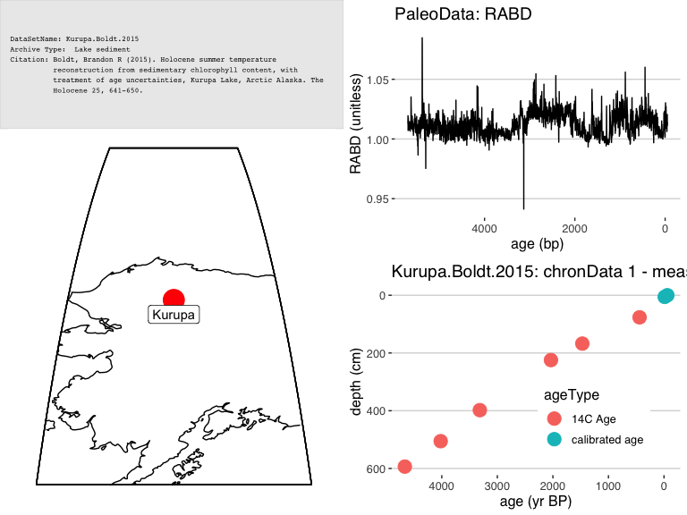

```r
sp <- plotSummary(K,paleo.data.var = "RABD",summary.font.size = 6)
```

```r
print(sp)
```

## Create an age model with Bacon

```r
K <- runBacon(K,
              lab.id.var = 'labID',
              age.14c.var = 'age14C',
              age.14c.uncertainty.var = 'age14CUncertainty',
              age.var = 'age',
              age.uncertainty.var = 'ageUncertainty',
              depth.var = 'depth',
              reservoir.age.14c.var = NULL,
              reservoir.age.14c.uncertainty.var = NULL,
              rejected.ages.var = NULL,
              bacon.acc.mean = 10,
              bacon.thick = 7,
              ask = FALSE,
              bacon.dir = "~/Cores",
              suggest = FALSE,
              close.connection = FALSE)
```

```
##  Using a mix of cal BP and calibrated C-14 dates
```

```
## Calculating age ranges...
```

```
## Preparing ghost graph...
```

```
##
## Mean 95% confidence ranges 317 yr, min. 4 yr at 0 cm, max. 518 yr at 308 cm
```

```
## 100% of the dates overlap with the age-depth model (95% ranges)
```

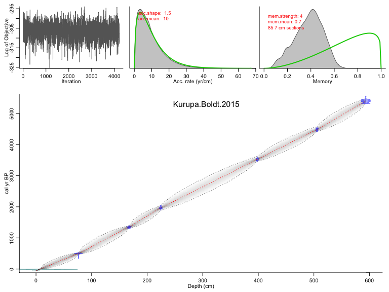

## And plot the ensemble output

```
## [1] "Found it! Moving on..."
## [1] "Found it! Moving on..."
## [1] "plotting your chron ensemble. This make take a few seconds..."
```

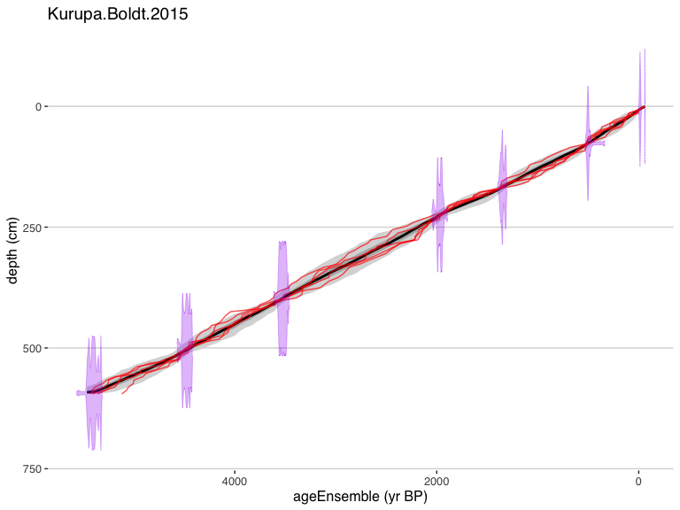

```r
plotChron(K,age.var = "ageEnsemble",dist.scale = 0.2)
```

## Map the age ensemble to the paleodata table

This is to get ensemble age estimates for each depth in the paleoData measurement table

```r
K <- mapAgeEnsembleToPaleoData(K,age.var = "ageEnsemble")
```

```
## [1] "Kurupa.Boldt.2015"
## [1] "Looking for age ensemble...."
## [1] "Found it! Moving on..."
## [1] "Found it! Moving on..."
## [1] "getting depth from the paleodata table..."
## [1] "Found it! Moving on..."
```

## Select the paleodata age ensemble, and RABD data that we’d like to regress and calibrate

```r
kae <-  selectData(K,"ageEnsemble")
```

```
## [1] "Found it! Moving on..."
```

```r
rabd <- selectData(K,"RABD")
```

```
## [1] "Found it! Moving on..."
```

## Now load in the instrumental data we want to correlate and regress agains

```r
kurupa.instrumental <- readr::read_csv("http://lipdverse.org/geochronr-examples/KurupaInstrumental.csv")
```

## Check age/time units before proceeding

```r
kae$units
```

```
## [1] "yr BP"
```

yep, we need to convert the units from BP to AD

```r
kae <- convertBP2AD(kae)
```

## Create a “variable list” for the instrumental data

```r
kyear <- list()
kyear$values <- kurupa.instrumental[,1]
kyear$variableName <- "year"
kyear$units <- "AD"

kinst <- list()
kinst$values <- kurupa.instrumental[,2]
kinst$variableName <- "Temperature"
kinst$units <- "deg (C)"
```

## Calculate an ensmeble correlation between the RABD and local summer temperature data

```r
corout <- corEns(kae,rabd,kyear,kinst,bin.step=2,percentiles = c(.05,.5,.95 ))
```

## And plot the output

Note that here we use the “Effective-N” significance option as we mimic the Boldt et al. (2015) paper.

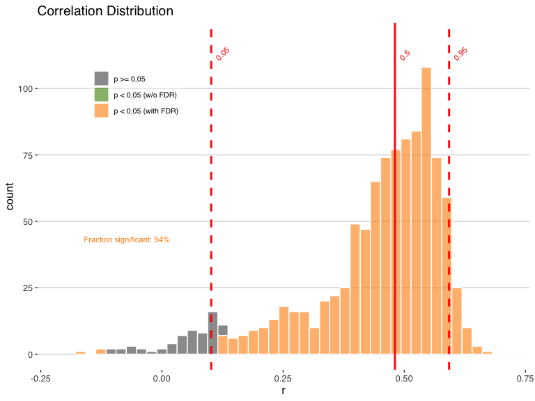

```r
plotCorEns(corout,significance.option = "eff-n")
```

Mixed results. But encouraging enough to move forward.

## Perform ensemble regression

OK, you’ve convinced yourself that you want to use RABD to model temperature back through time. We can do this simply (perhaps naively) with regession, and lets do it with age uncertainty, both in the building of the model, and the reconstructing

```r
regout <- regressEns(time.x = kae,
                    values.x = rabd,
                    time.y =kyear,
                    values.y =kinst,
                    bin.step=3,
                    gaussianize = FALSE,
                    recon.bin.vec = seq(-4010,2010,by=20))
```

## And plot the output

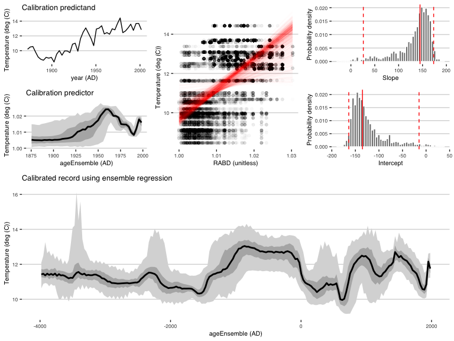

```r
regPlots <- plotRegressEns(regout,alp = 0.01,font.size = 8)
```

This result is consistent with that produced by Boldt et al., (2015), and was much simpler to produce with GeoChronR.

[output not shown]